# HW2

1A.

```r
country_population <- readr::read_csv("https://raw.githubusercontent.com/linnykos/561_s2024_public/main/HW2_files/country_population.csv")
country_population
```

```
#> # A tibble: 13,545 × 4
#>    iso3c country  year population
#>    <chr> <chr>   <dbl>      <dbl>
#>  1 ABW   Aruba    1960      54608
#>  2 ABW   Aruba    1961      55811
#>  3 ABW   Aruba    1962      56682
#>  4 ABW   Aruba    1963      57475
#>  5 ABW   Aruba    1964      58178
#>  6 ABW   Aruba    1965      58782
#>  7 ABW   Aruba    1966      59291
#>  8 ABW   Aruba    1967      59522
#>  9 ABW   Aruba    1968      59471
#> 10 ABW   Aruba    1969      59330
#> # ℹ 13,535 more rows
```

```r
country_birth <- readr::read_csv("https://raw.githubusercontent.com/linnykos/561_s2024_public/main/HW2_files/country_birth.csv")
options(scipen = 100)
country_population <- country_population %>%
  filter(year >= 1990 & year <= 2010) %>%
  group_by(iso3c, country) %>%
  summarize(mean_population = mean(population))
country_population
```

```
#> # A tibble: 215 × 3
#> # Groups:   iso3c [215]
#>    iso3c country              mean_population
#>    <chr> <chr>                          <dbl>
#>  1 ABW   Aruba                         85839.
#>  2 AFG   Afghanistan                19819866.
#>  3 AGO   Angola                     16829911.
#>  4 ALB   Albania                     3095489.
#>  5 AND   Andorra                       67825.
#>  6 ARE   United Arab Emirates        3858774.
#>  7 ARG   Argentina                  36972314.
#>  8 ARM   Armenia                     3211816.
#>  9 ASM   American Samoa                54995.
#> 10 ATG   Antigua and Barbuda           74385.
#> # ℹ 205 more rows
```

1B.

```r
country_birth <- country_birth %>%
  filter(year >= 1990 & year <= 2010) %>%
  filter(!is.na(iso3c), !is.na(year), !is.na(life_expect)) %>%
  group_by(iso3c) %>%
  summarize(max_life_expect = max(life_expect), min_life_expect = min(life_expect)) %>%
  mutate(range_life_expect = max_life_expect - min_life_expect)
country_birth
```

```
#> # A tibble: 203 × 4
#>    iso3c max_life_expect min_life_expect range_life_expect
#>    <chr>           <dbl>           <dbl>             <dbl>
#>  1 ABW              75.0            73.4              1.56
#>  2 AFG              59.0            49.9              9.11
#>  3 AGO              50.7            41.1              9.52
#>  4 ALB              77.0            71.9              5.14
#>  5 ARE              76.7            71.7              4.96
#>  6 ARG              75.5            71.5              3.94
#>  7 ARM              74.2            67.7              6.49
#>  8 ATG              75.3            71.2              4.15
#>  9 AUS              81.7            77.0              4.70
#> 10 AUT              80.6            75.6              5.01
#> # ℹ 193 more rows
```

1C. There are 202 rows and 6 columns in country_both.

```r
country_both <- inner_join(country_population, country_birth, join_by(iso3c))
tibble(country_both)
```

```
#> # A tibble: 202 × 6
#>    iso3c country              mean_population max_life_expect min_life_expect range_life_expect
#>    <chr> <chr>                          <dbl>           <dbl>           <dbl>             <dbl>
#>  1 ABW   Aruba                         85839.            75.0            73.4              1.56
#>  2 AFG   Afghanistan                19819866.            59.0            49.9              9.11
#>  3 AGO   Angola                     16829911.            50.7            41.1              9.52
#>  4 ALB   Albania                     3095489.            77.0            71.9              5.14
#>  5 ARE   United Arab Emirates        3858774.            76.7            71.7              4.96
#>  6 ARG   Argentina                  36972314.            75.5            71.5              3.94
#>  7 ARM   Armenia                     3211816.            74.2            67.7              6.49
#>  8 ATG   Antigua and Barbuda           74385.            75.3            71.2              4.15
#>  9 AUS   Australia                  19200991.            81.7            77.0              4.70
#> 10 AUT   Austria                     8057573.            80.6            75.6              5.01
#> # ℹ 192 more rows
```

2A.

```r
penguins <- readr::read_csv("https://raw.githubusercontent.com/linnykos/561_s2024_public/main/HW2_files/palmerpenguins.csv")
```

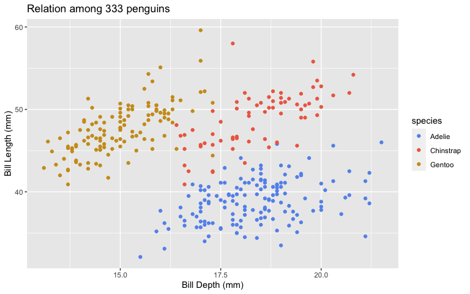

```r
penguins %>%
  ggplot(aes(x = bill_depth_mm, y = bill_length_mm, col=species)) +
  geom_point() +
  labs(x = 'Bill Depth (mm)', y = 'Bill Length (mm)', title = paste("Relation among", nrow(penguins), "penguins")) +
  scale_color_manual(values = c("Adelie" = "cornflowerblue", "Chinstrap" = "coral2", "Gentoo" = "goldenrod3"))
```

2B.

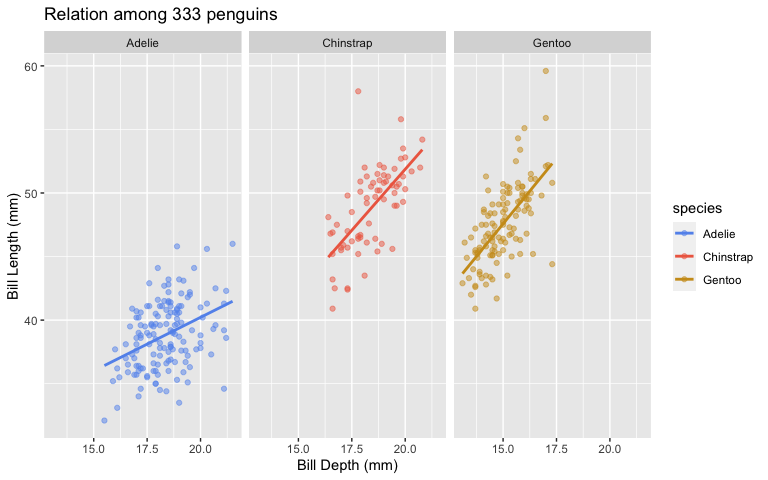

```r
penguins %>%
  ggplot(aes(x = bill_depth_mm, y = bill_length_mm, col=species)) +
  geom_point(alpha=0.5) +
  facet_wrap(~species) +
  geom_smooth(method = "lm", se = FALSE) +
  labs(x = 'Bill Depth (mm)', y = 'Bill Length (mm)', title = paste("Relation among", nrow(penguins), "penguins")) +
  scale_color_manual(values = c("Adelie" = "cornflowerblue", "Chinstrap" = "coral2", "Gentoo" = "goldenrod3"))
```

3A. The generate_random_graph function creates a randomized adjacency matrix for a graph with a specific number of nodes, a set probability of edges, and an embedded clique. After checking if the arguments are correct, it generates a nxn matrix of 0s and 1s and then makes the matrix is symmetric. It forms a clique within the matrix which is a subset of nodes where every two distinct nodes are different and then randomizes the order of the nodes in the adjacency matrix while also computing the reverse order in order to revert back to the original matrix if necessary. Then is outputs a list with the randomized adjacency matrix and the reverse order of the nodes.

```r
source("https://raw.githubusercontent.com/linnykos/561_s2024_public/main/HW2_files/random_graph_functions.R")
set.seed(0)
result <- generate_random_graph(n = 20,
                                clique_fraction = 0.5,
                                density_low = 0.1)
adj_mat <- result$adj_mat
dim(adj_mat)
```

```
#> [1] 20 20
```

```r
adj_mat[1:5,1:5]
```

```
#>      [,1] [,2] [,3] [,4] [,5]
#> [1,]    1    0    1    0    0
#> [2,]    0    1    1    1    1
#> [3,]    1    1    1    0    0
#> [4,]    0    1    0    1    0
#> [5,]    0    1    0    0    1
```

3B. The pivot_longer_heatmap function converts an adjacency matrix into a long format suitable for creating heatmaps. It first converts the adjacency matrix into a tibble and assigns column names based on the node identifiers. It then reshapes the tibble from a wide format into a long format using pivto_longer() which reshapes the matrix such that each row represents an individual connection between two nodes X and Y. Then it renames the column names and outputs a long format of the adjacency matrix. This output basically just looks at each ‘cell’ in the adjaceny matrix and lists it’s X and Y value as well as the value present in that cell.

```r
mat_long <- pivot_longer_heatmap(adj_mat)
mat_long
```

```
#> # A tibble: 400 × 3
#>        X     Y Value
#>    <int> <dbl> <dbl>
#>  1     1     1     1
#>  2     1     2     0
#>  3     1     3     1
#>  4     1     4     0
#>  5     1     5     0
#>  6     1     6     1
#>  7     1     7     0
#>  8     1     8     0
#>  9     1     9     0
#> 10     1    10     0
#> # ℹ 390 more rows
```

3C.

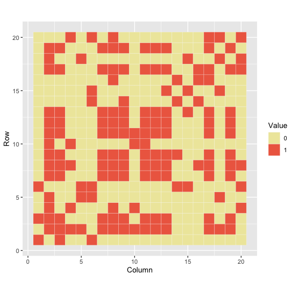

```r
cols <- c("0" = "palegoldenrod", "1" = "coral2")
mat_long %>%
  ggplot(aes(x = X, y = Y, fill = factor(Value))) + geom_tile(color="white") +
  scale_fill_manual(values = cols) + coord_fixed(ratio = 1) + labs(x = "Column", y = "Row") +
  guides(fill = guide_legend(title = "Value"))
```

3D. The code below undoes the randomization initially applied to the original adjacency matrix and restores the nodes to their initial order. So adj_mat2 is the adjacency matrix in its original order.

```r
adj_mat2 <- result$adj_mat[result$rev_order, result$rev_order]
mat_long2 <- pivot_longer_heatmap(adj_mat2)
mat_long2
```

```
#> # A tibble: 400 × 3
#>        X     Y Value
#>    <int> <dbl> <dbl>
#>  1     1     1     1
#>  2     1     2     1
#>  3     1     3     1
#>  4     1     4     1
#>  5     1     5     1
#>  6     1     6     1
#>  7     1     7     1
#>  8     1     8     1
#>  9     1     9     1
#> 10     1    10     1
#> # ℹ 390 more rows
```

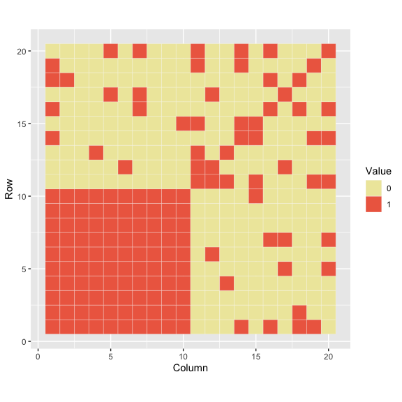

```r
cols <- c("0" = "palegoldenrod", "1" = "coral2")
mat_long2 %>%
  ggplot(aes(x = X, y = Y, fill = factor(Value))) + geom_tile(color="white") +
  scale_fill_manual(values = cols) + coord_fixed(ratio = 1) + labs(x = "Column", y = "Row") +
  guides(fill = guide_legend(title = "Value"))
```

4. In order to test this function I would use a few different methods. First, I would create a few adjacency matrices where the maximal clique can be easily verified by hand and run them through the function to compare the output to the expected result, this would include matrices with a number of variations of cliques including matrices with no cliques. I would also run random matrices through the function that have predetermined clique properties to compare the functions output to the expected result. I would also test extreme scenarios, such as really sparse, dense, or large matrices to see how it performs. And lastly, if there is already any known software that performs this function, I would compare the output from our function to the preexisting software for further verification.